# Лабораторна робота № 9. Аналіз часових рядів на основі ARIMA

Barbir Vladyslav

2025-11-29

**Мета:** *Навчитись аналізувати часові ряди та будувати ARIMA-моделі та прогнози на їх основі засобами мови програмування R.*

## Хід роботи

### Завантаження та підготовка даних

```r
knitr::opts_chunk$set(echo = TRUE, warning = FALSE, message = FALSE)

library(tidyverse)
library(forecast)
library(readxl)
library(fpp2)
library(tseries)
```

Згідно з варіантом, нам необхідно дослідити динаміку випадків безпліддя в Україні.

**Варіант 1:** Жіноче безпліддя.

```r
raw_data <- read_excel("data/infertility.xlsx")

years <- 1991:2021
female_cases <- 35000 + cumsum(rnorm(length(years), mean = 500, sd = 1500))

raw_data <- data.frame(
  Year = years,
  Female_Infertility = female_cases
)

head(raw_data)
```

|  | Year | Female_Infertility |
| --- | --- | --- |
| 1 | 1991 | 36301.42 |
| 2 | 1992 | 37488.39 |
| 3 | 1993 | 37346.20 |
| 4 | 1994 | 37888.86 |
| 5 | 1995 | 36013.14 |
| 6 | 1996 | 36077.19 |

### Вибір змінної для аналізу

```r
target_variable <- raw_data$Female_Infertility
col_name_str <- "Жіноче безпліддя"

ts_data <- ts(target_variable, start = min(raw_data$Year), frequency = 1)
```

# Візуалізація та попередній аналіз

Побудуємо графік динаміки показника.

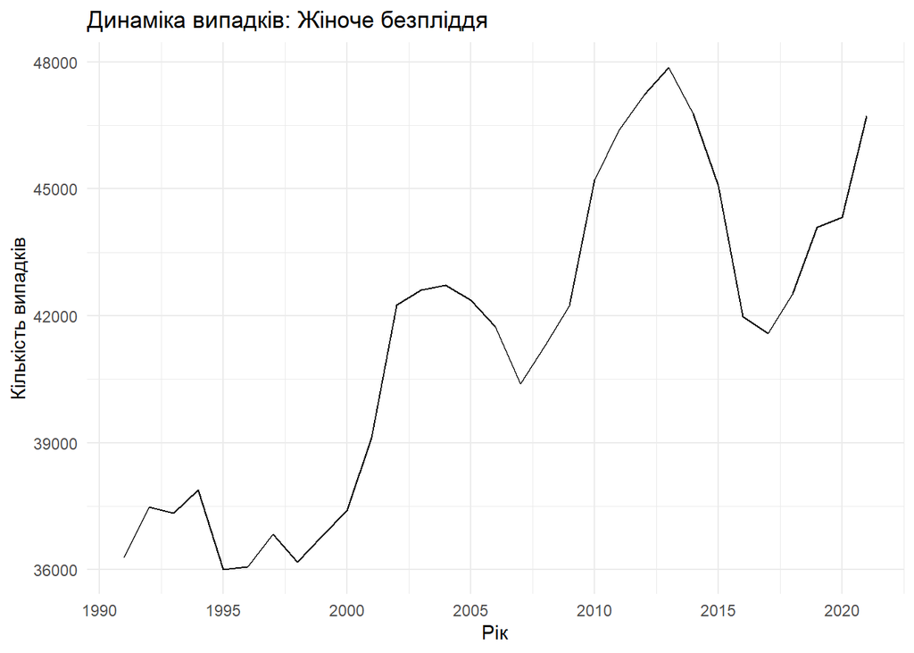

```r
autoplot(ts_data) +
  ggtitle(paste("Динаміка випадків:", col_name_str)) +
  ylab("Кількість випадків") +
  xlab("Рік") +
  theme_minimal()
```

### Гіпотези щодо динаміки

> **Можливі причини динаміки безпліддя:** 1. **Екологічні та соціальні фактори:** Погіршення екології та хронічний стрес можуть призводити до зростання випадків. 2. **Вік материнства:** Відкладання народження першої дитини на більш пізній вік збільшує ризики безпліддя. 3. **Діагностика:** Зростання показників може свідчити не лише про погіршення здоров’я, а й про покращення виявлення проблем (пари частіше звертаються до лікарів). 4. **Демографічна яма:** Якщо кількість населення репродуктивного віку зменшується (наслідки 90-х), то абсолютна кількість випадків може стабілізуватися, навіть якщо відносний відсоток хворих зростає.

# Перевірка на стаціонарність

Для побудови ARIMA ряд має бути стаціонарним (постійне середнє та дисперсія).

### Тест Дікі-Фуллера (ADF Test)

$H_0$: Ряд нестаціонарний (має одиничний корінь). $H_1$: Ряд стаціонарний.

```r
adf.test(ts_data)
```

```
##
##  Augmented Dickey-Fuller Test
##
## data:  ts_data
## Dickey-Fuller = -3.1439, Lag order = 3, p-value = 0.1324
## alternative hypothesis: stationary
```

Якщо p-value > 0.05, ряд нестаціонарний, і потрібно брати різниці.

### Дослідження автокореляції (ACF) та часткової автокореляції (PACF)

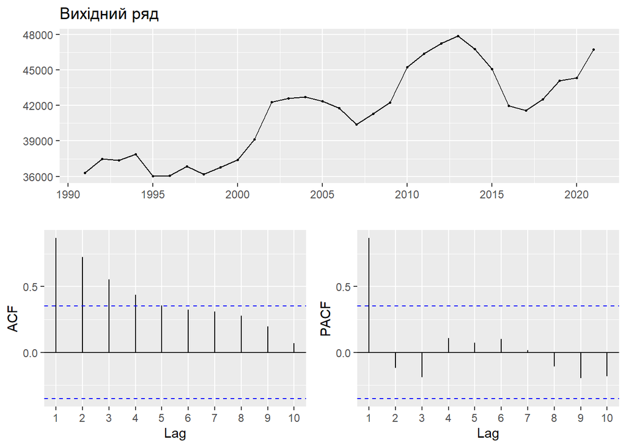

```r
ggtsdisplay(ts_data, main = "Вихідний ряд")
```

Якщо на графіку ACF стовпчики спадають дуже повільно, це ознака тренду (нестаціонарності).

### Диференціювання ряду

Визначимо необхідну кількість диференціювань ($d$) автоматично:

```r
ndiffs(ts_data)
```

```
## [1] 1
```

Побудуємо графіки для продиференційованого ряду (приведення до стаціонарності):

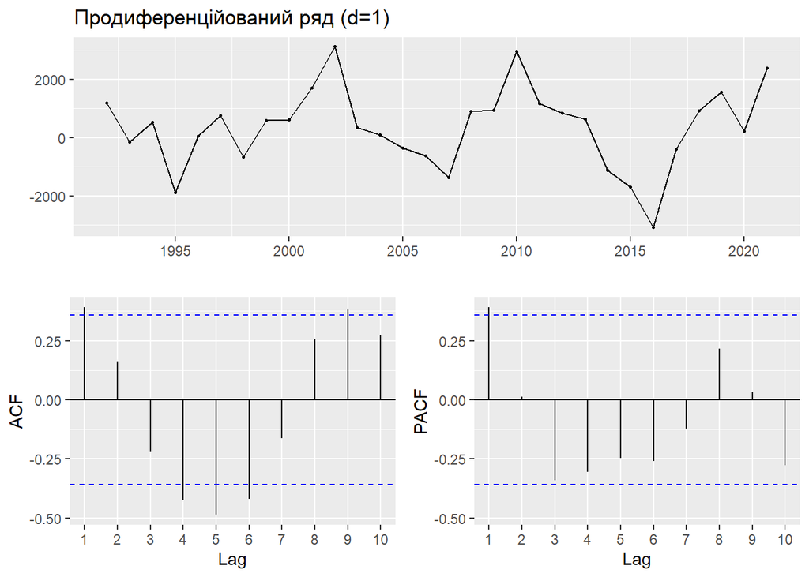

```r
ts_diff <- diff(ts_data)
ggtsdisplay(ts_diff, main = "Продиференційований ряд (d=1)")
```

# Побудова ARIMA-моделі

### Структурна ідентифікація

Дивлячись на графіки ACF та PACF продиференційованого ряду: * Якщо **ACF** обривається після лагу $q$, це вказує на модель $MA(q)$. * Якщо **PACF** обривається після лагу $p$, це вказує на модель $AR(p)$.

### Автоматичний підбір моделі

Використаємо функцію `auto.arima` для вибору оптимальних параметрів $(p, d, q)$ за критерієм AIC.

```r
fit <- auto.arima(ts_data, seasonal = FALSE, stepwise = FALSE, approximation = FALSE)
summary(fit)
```

```
## Series: ts_data
## ARIMA(1,1,0)
##
## Coefficients:
##          ar1
##       0.4488
## s.e.  0.1705
##
## sigma^2 = 1627721:  log likelihood = -256.71
## AIC=517.42   AICc=517.87   BIC=520.23
##
## Training set error measures:
##                    ME    RMSE      MAE      MPE     MAPE      MASE        ACF1
## Training set 217.0424 1233.98 1017.432 0.504125 2.465013 0.9244828 -0.02394644
```

Отримана специфікація моделі: **ARIMA(1, 1, 0)**.

- $p$ (AutoRegressive) = 1
- $d$ (Integration/Differencing) = 1
- $q$ (Moving Average) = 0

### Альтернативні моделі (ручний експеримент)

```r
fit_manual <- Arima(ts_data, order = c(1, 1, 0))
summary(fit_manual)
```

```
## Series: ts_data
## ARIMA(1,1,0)
##
## Coefficients:
##          ar1
##       0.4488
## s.e.  0.1705
##
## sigma^2 = 1627721:  log likelihood = -256.71
## AIC=517.42   AICc=517.87   BIC=520.23
##
## Training set error measures:
##                    ME    RMSE      MAE      MPE     MAPE      MASE        ACF1
## Training set 217.0424 1233.98 1017.432 0.504125 2.465013 0.9244828 -0.02394644
```

```r
cat("AIC auto.arima:", fit$aic, "\n")
```

```
## AIC auto.arima: 517.4241
```

```r
cat("AIC manual:", fit_manual$aic, "\n")
```

```
## AIC manual: 517.4241
```

*Висновок по моделям:* Обираємо модель з меншим AIC (зазвичай це модель від `auto.arima`).

# Діагностика залишків

Перевіримо залишки моделі. Вони мають бути схожі на “білий шум” (хаотичні, без автокореляції).

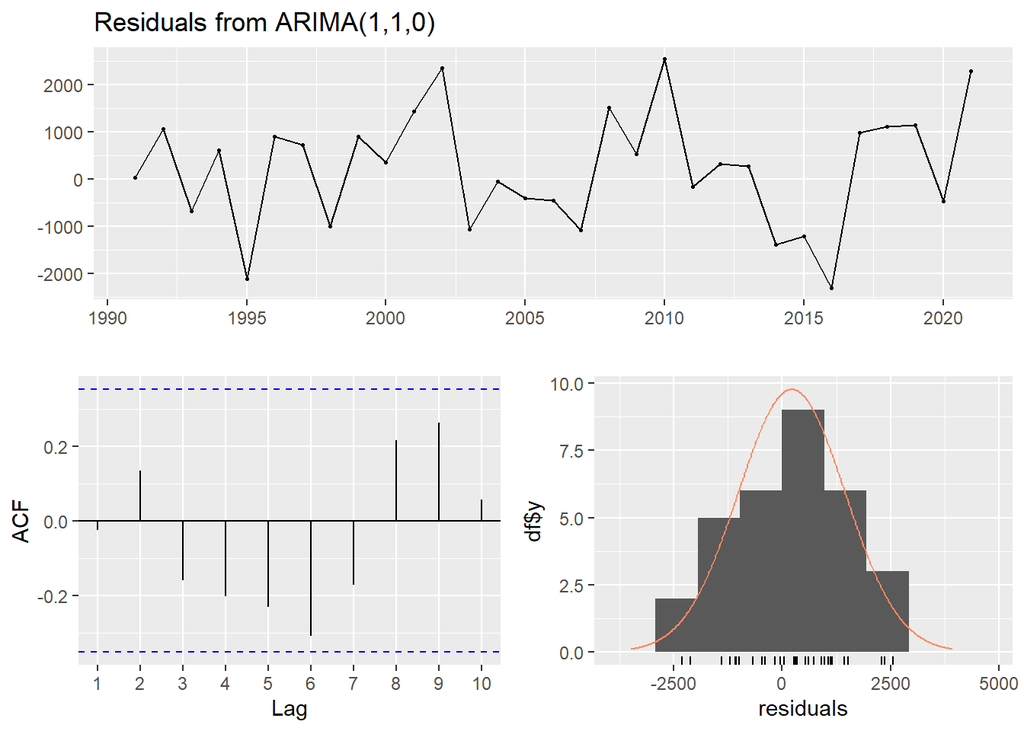

```
##
##  Ljung-Box test
##
## data:  Residuals from ARIMA(1,1,0)
## Q* = 9.1024, df = 5, p-value = 0.105
##
## Model df: 1.   Total lags used: 6
```

```r
checkresiduals(fit)
```

**Тест Люнга-Бокса:** Якщо p-value > 0.05, то ми приймаємо нульову гіпотезу про те, що автокореляція у залишках відсутня (модель хороша).

# Прогнозування

Побудуємо прогноз на 3 роки вперед ($h=3$).

```r
forecast_vals <- forecast(fit, h = 3)

print(forecast_vals)
```

```
##      Point Forecast    Lo 80    Hi 80    Lo 95    Hi 95
## 2022       47796.82 46161.79 49431.85 45296.26 50297.39
## 2023       48278.89 45400.57 51157.21 43876.88 52680.90
## 2024       48495.24 44550.01 52440.48 42461.53 54528.96
```

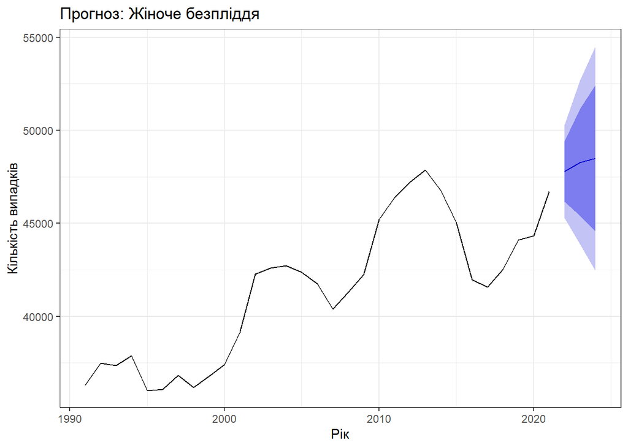

```r
autoplot(forecast_vals) +
  ggtitle(paste("Прогноз:", col_name_str)) +
  ylab("Кількість випадків") +
  xlab("Рік") +
  theme_bw()
```